# MBAN - Winter 2024 Assignment 4

MBAN - Winter 2024

Author

Fatemeh Shahriari, Zhengbin Wang, Afif Tahsin

# 1 1. Get the data and prepare it

## 1.1 1. Check for missing values,

```r
#load libraries
library(ggplot2)
library(RBootcamp)
library(caret)
library(randomForest)
library(ROCR)
library(PASWR)
library(rpart)
library(rpart.plot)
```

```r
#load the data with header
data <- read.csv("bank.csv", header = TRUE)
```

```r
# check the structure of the data
str(data)
```

```
'data.frame':   4521 obs. of  1 variable:
 $ age.job.marital.education.default.balance.housing.loan.contact.day.month.duration.campaign.pdays.previous.poutcome.y: chr  "30;unemployed;married;primary;no;1787;no;no;cellular;19;oct;79;1;-1;0;unknown;no" "33;services;married;secondary;no;4789;yes;yes;cellular;11;may;220;1;339;4;failure;no" "35;…
```

```r
# how to fix the structure of the data

# Split the data into separate columns based on semicolons
split_data <- strsplit(data$age.job.marital.education.default.balance.housing.loan.contact.day.month.duration.campaign.pdays.previous.poutcome.y, ";")

# Convert the list of vectors into a data frame
df <- as.data.frame(do.call(rbind, split_data))
```

```r
#check data overview
str(df)
```

```
'data.frame':   4521 obs. of  17 variables:
 $ V1 : chr  "30" "33" "35" "30" ...
 $ V2 : chr  "unemployed" "services" "management" "management" ...
 $ V3 : chr  "married" "married" "single" "married" ...
 $ V4 : chr  "primary" "secondary" "tertiary" "tertiary" ...
 $ V5 : chr  "no" "no" "no" "no" ...
 $ V6 : chr  "1787" "4789" "1350" "1476" ...
 $ V7 : chr  "no" "yes" "yes" "yes" ...
 $ V8 : chr  "no" "yes" "no" "yes" ...
 $ V9 : chr  "cellular" "cellular" "cellular" "unknown" ...
 $ V10: chr  "19" "11" "16" "3" ...
 $ V11: chr  "oct" "may" "apr" "jun" ...
 $ V12: chr  "79" "220" "185" "199" ...
 $ V13: chr  "1" "1" "1" "4" ...
 $ V14: chr  "-1" "339" "330" "-1" ...
 $ V15: chr  "0" "4" "1" "0" ...
 $ V16: chr  "unknown" "failure" "failure" "unknown" ...
 $ V17: chr  "no" "no" "no" "no" ...
```

```r
summary(df)
```

```
      V1                 V2                 V3                 V4
 Length:4521        Length:4521        Length:4521        Length:4521
 Class :character   Class :character   Class :character   Class :character
 Mode  :character   Mode  :character   Mode  :character   Mode  :character
      V5                 V6                 V7                 V8
 Length:4521        Length:4521        Length:4521        Length:4521
 Class :character   Class :character   Class :character   Class :character
 Mode  :character   Mode  :character   Mode  :character   Mode  :character
      V9                V10                V11                V12
 Length:4521        Length:4521        Length:4521        Length:4521
 Class :character   Class :character   Class :character   Class :character
 Mode  :character   Mode  :character   Mode  :character   Mode  :character
     V13                V14                V15                V16
 Length:4521        Length:4521        Length:4521        Length:4521
 Class :character   Class :character   Class :character   Class :character
 Mode  :character   Mode  :character   Mode  :character   Mode  :character
     V17
 Length:4521
 Class :character
 Mode  :character
```

```r
# Rename columns
names(df) <- c("age", "job", "marital", "education", "default", "balance", "housing", "loan", "contact", "day", "month", "duration", "campaign", "pdays", "previous", "poutcome", "y")
```

```r
# Convert numeric columns to appropriate data types
numeric_cols <- c("age", "balance", "day", "duration", "campaign", "pdays", "previous")
df[numeric_cols] <- lapply(df[numeric_cols], as.numeric)
```

```r
#make a copy of the df
df1 <- df
```

```r
#change all chr variables into factor variables
chr_vars <- sapply(df1, is.character)

df1[chr_vars] <- lapply(df1[chr_vars], factor)
```

```r
#check if there are any levels with less than 10 observations

numeric_vars <- sapply(df1, is.numeric)

sapply(df1[!numeric_vars], function(x) table(x)[table(x) < 10])
```

```
$job
named integer(0)

$marital
named integer(0)

$education
named integer(0)

$default
named integer(0)

$housing
named integer(0)

$loan
named integer(0)

$contact
named integer(0)

$month
named integer(0)

$poutcome
named integer(0)

$y
named integer(0)
```

```r
#show the count of each unique levels within each factor variable
factor_vars <- sapply(df1, is.factor)
sapply(df1[factor_vars], function(x) length(unique(x)))
```

```
      job   marital education   default   housing      loan   contact     month
       12         3         4         2         2         2         3        12
 poutcome         y
        4         2
```

```r
sapply(df1[factor_vars], function(x) table(x)) #show the count of each unique levels within each factor variable
```

```
$job
x
       admin.   blue-collar  entrepreneur     housemaid    management
          478           946           168           112           969
      retired self-employed      services       student    technician
          230           183           417            84           768
   unemployed       unknown
          128            38

$marital
x
divorced  married   single
     528     2797     1196

$education
x
  primary secondary  tertiary   unknown
      678      2306      1350       187

$default
x
  no  yes
4445   76

$housing
x
  no  yes
1962 2559

$loan
x
  no  yes
3830  691

$contact
x
 cellular telephone   unknown
     2896       301      1324

$month
x
 apr  aug  dec  feb  jan  jul  jun  mar  may  nov  oct  sep
 293  633   20  222  148  706  531   49 1398  389   80   52

$poutcome
x
failure   other success unknown
    490     197     129    3705

$y
x
  no  yes
4000  521
```

```r
# Identify Zero-Variance predictors
zeroVar <- nearZeroVar(df1, saveMetrics = TRUE)
zeroVar
```

```
           freqRatio percentUnique zeroVar   nzv
age         1.031250      1.481973   FALSE FALSE
job         1.024313      0.265428   FALSE FALSE
marital     2.338629      0.066357   FALSE FALSE
education   1.708148      0.088476   FALSE FALSE
default    58.486842      0.044238   FALSE  TRUE
balance    14.875000     52.046008   FALSE FALSE
housing     1.304281      0.044238   FALSE FALSE
loan        5.542692      0.044238   FALSE FALSE
contact     2.187311      0.066357   FALSE FALSE
day         1.137168      0.685689   FALSE FALSE
month       1.980170      0.265428   FALSE FALSE
duration    1.080000     19.354125   FALSE FALSE
campaign    1.371835      0.707808   FALSE FALSE
pdays     161.086957      6.458748   FALSE  TRUE
previous   12.954545      0.530856   FALSE FALSE
poutcome    7.561224      0.088476   FALSE FALSE
y           7.677543      0.044238   FALSE FALSE
```

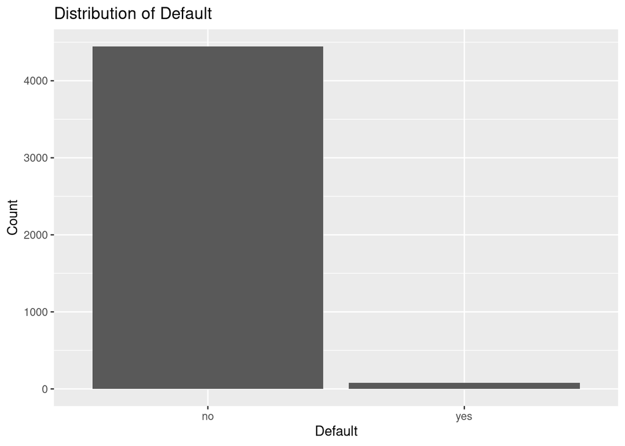

```r
#plot distribution of default
ggplot(df1, aes(x = default)) +
  geom_bar() +
  labs(title = "Distribution of Default", x = "Default", y = "Count")
```

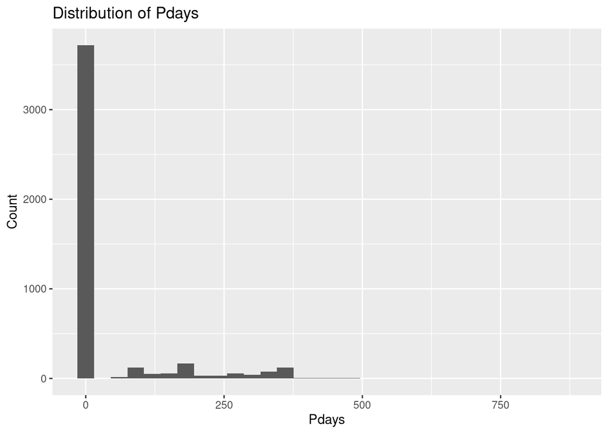

```r
#plot historgram of pdays
ggplot(df1, aes(x = pdays)) +
  geom_histogram() +
  labs(title = "Distribution of Pdays", x = "Pdays", y = "Count")
```

```r
#check sd again for new numerical columns
numeric_vars <- sapply(df1, is.numeric)
#check only the standard deviation of the numeric variables
sapply(df1[numeric_vars], sd)
```

```
        age     balance         day    duration    campaign       pdays
  10.576211 3009.638142    8.247667  259.856633    3.109807  100.121124
   previous
   1.693562
```

```r
#check variance of the numeric variables without scientific notation
options(scipen=999)
sapply(df1[numeric_vars], var)
```

```
           age        balance            day       duration       campaign
    111.856238 9057921.748594      68.024016   67525.469519       9.670897
         pdays       previous
  10024.239560       2.868153
```

```r
#check the contact variable using table
table(df1$contact)
```

```
 cellular telephone   unknown
     2896       301      1324
```

```r
#check the previous variable using table
table(df1$previous)
```

```
   0    1    2    3    4    5    6    7    8    9   10   11   12   13   14   15
3705  286  193  113   78   47   25   22   18   10    4    3    5    1    2    1
  17   18   19   20   22   23   24   25
   1    1    1    1    1    1    1    1
```

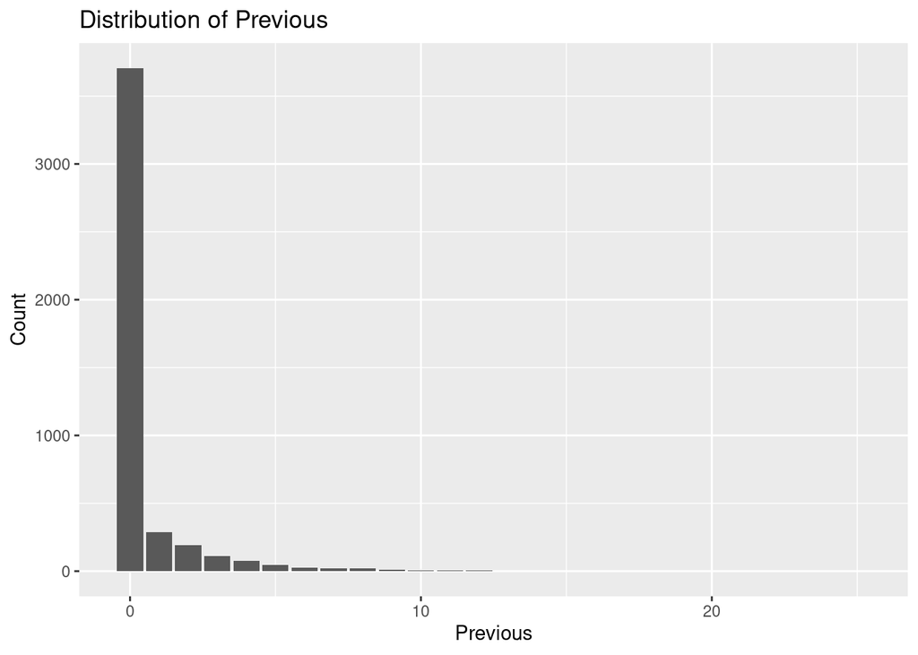

```r
#plot distribution of previous
ggplot(df1, aes(x = previous)) +
  geom_bar() +
  labs(title = "Distribution of Previous", x = "Previous", y = "Count")
```

#### 1.1.0.1 Variable “previous” has a lot of zeros and highly skewed

## 1.2 2. Check out the class balance

```r
#check the class balance
table(df1$y)
```

```
  no  yes
4000  521
```

```r
prop.table(table(df1$y))
```

```
     no     yes
0.88476 0.11524
```

it is heavily leaning towards no

```r
#check data overview
str(df1)
```

```
'data.frame':   4521 obs. of  17 variables:
 $ age      : num  30 33 35 30 59 35 36 39 41 43 ...
 $ job      : Factor w/ 12 levels "admin.","blue-collar",..: 11 8 5 5 2 5 7 10 3 8 ...
 $ marital  : Factor w/ 3 levels "divorced","married",..: 2 2 3 2 2 3 2 2 2 2 ...
 $ education: Factor w/ 4 levels "primary","secondary",..: 1 2 3 3 2 3 3 2 3 1 ...
 $ default  : Factor w/ 2 levels "no","yes": 1 1 1 1 1 1 1 1 1 1 ...
 $ balance  : num  1787 4789 1350 1476 0 ...
 $ housing  : Factor w/ 2 levels "no","yes": 1 2 2 2 2 1 2 2 2 2 ...
 $ loan     : Factor w/ 2 levels "no","yes": 1 2 1 2 1 1 1 1 1 2 ...
 $ contact  : Factor w/ 3 levels "cellular","telephone",..: 1 1 1 3 3 1 1 1 3 1 ...
 $ day      : num  19 11 16 3 5 23 14 6 14 17 ...
 $ month    : Factor w/ 12 levels "apr","aug","dec",..: 11 9 1 7 9 4 9 9 9 1 ...
 $ duration : num  79 220 185 199 226 141 341 151 57 313 ...
 $ campaign : num  1 1 1 4 1 2 1 2 2 1 ...
 $ pdays    : num  -1 339 330 -1 -1 176 330 -1 -1 147 ...
 $ previous : num  0 4 1 0 0 3 2 0 0 2 ...
 $ poutcome : Factor w/ 4 levels "failure","other",..: 4 1 1 4 4 1 2 4 4 1 ...
 $ y        : Factor w/ 2 levels "no","yes": 1 1 1 1 1 1 1 1 1 1 ...
```

```r
summary(df1)
```

```
      age                 job          marital         education    default
 Min.   :19.00   management :969   divorced: 528   primary  : 678   no :4445
 1st Qu.:33.00   blue-collar:946   married :2797   secondary:2306   yes:  76
 Median :39.00   technician :768   single  :1196   tertiary :1350
 Mean   :41.17   admin.     :478                   unknown  : 187
 3rd Qu.:49.00   services   :417
 Max.   :87.00   retired    :230
                 (Other)    :713
    balance      housing     loan           contact          day
 Min.   :-3313   no :1962   no :3830   cellular :2896   Min.   : 1.00
 1st Qu.:   69   yes:2559   yes: 691   telephone: 301   1st Qu.: 9.00
 Median :  444                         unknown  :1324   Median :16.00
 Mean   : 1423                                          Mean   :15.92
 3rd Qu.: 1480                                          3rd Qu.:21.00
 Max.   :71188                                          Max.   :31.00

     month         duration       campaign          pdays
 may    :1398   Min.   :   4   Min.   : 1.000   Min.   : -1.00
 jul    : 706   1st Qu.: 104   1st Qu.: 1.000   1st Qu.: -1.00
 aug    : 633   Median : 185   Median : 2.000   Median : -1.00
 jun    : 531   Mean   : 264   Mean   : 2.794   Mean   : 39.77
 nov    : 389   3rd Qu.: 329   3rd Qu.: 3.000   3rd Qu.: -1.00
 apr    : 293   Max.   :3025   Max.   :50.000   Max.   :871.00
 (Other): 571
    previous          poutcome      y
 Min.   : 0.0000   failure: 490   no :4000
 1st Qu.: 0.0000   other  : 197   yes: 521
 Median : 0.0000   success: 129
 Mean   : 0.5426   unknown:3705
 3rd Qu.: 0.0000
 Max.   :25.0000
```

```r
#scale the numeric variables (optional)
#df1[numeric_vars] <- lapply(df1[numeric_vars], scale)

#create a surrogate variable for y
df1$y_surrogate <- ifelse(df1$y == "yes", 1, 0)

#check the correlation matrix to y and y is not numeric

cor(df1[numeric_vars], df1$y_surrogate)
```

```
                   [,1]
age          0.04509180
balance      0.01790510
day         -0.01124421
duration     0.40111830
campaign    -0.06114743
pdays        0.10408682
previous     0.11671444
y_surrogate  1.00000000
```

```r
#remove the surrogate variable and scale numeric variables
df1 <- df1[, -which(names(df1) %in% c("y_surrogate"))]

df_copy <- df1
```

# 2 Random Forest and LPM

## 2.1 1. Report the test AUC and its 95% CI for both models with 100 bootstrap loops.

### 2.1.1 Getting Test AUC for Random Forest with 100 Bootstrapping loops

```r
#an function to unregister the dopar if needed
unregister_dopar <- function() {
  env <- foreach:::.foreachGlobals
  rm(list=ls(name=env), pos=env)
}
```

```r
library(parallel)
library(randomForest)
library(pROC)

n <- nrow(df1)
num_cores <- detectCores() # Use all available cores

result <- mclapply(1:100, function(i) {
  set.seed(i)
  train_idx <- sample(n, n, replace = TRUE)
  train <- df1[train_idx, ]
  test <- df1[-train_idx, ]

  rf_model_test <- randomForest(y ~ ., data = train, ntree = 1500)
  phat <- predict(rf_model_test, test, type = "prob")[, 2]

  roc_curve <- roc(test$y, phat)
  auc_score <- auc(roc_curve)

  list(auc_score = auc_score, model = rf_model_test)
}, mc.cores = num_cores)

# Combine the results
AUC_test <- sapply(result, function(x) x$auc_score)
rf_model_test <- lapply(result, function(x) x$model)

# Get the index of the best AUC
best_index <- which.max(AUC_test)

# Get the best model
best_model <- rf_model_test[[best_index]]
```

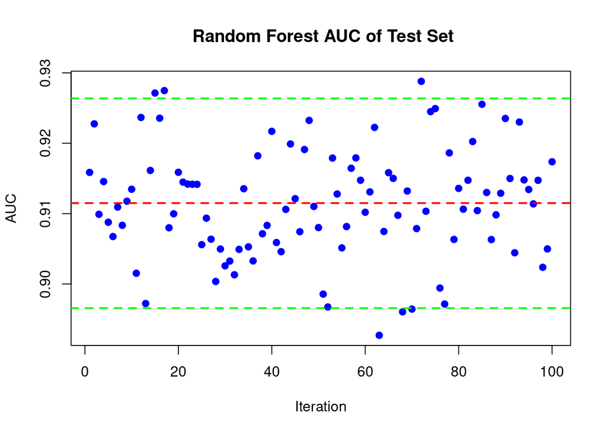

```r
#plot the Random Forest AUC
#plot result based 95% CI
plot(AUC_test, pch = 19, col = "blue", xlab = "Iteration", ylab = "AUC", main = " Random Forest AUC of Test Set")
abline(h = mean(AUC_test), lwd = 2, lty = 2, col = "red")
abline(h = quantile(AUC_test, 0.025), lwd = 2, lty = 2, col = "green")
abline(h = quantile(AUC_test, 0.975), lwd = 2, lty = 2, col = "green")
```

```r
#calculate the mean AUC
mean(AUC_test)
```

```
[1] 0.9114931
```

## 2.2 OOB Confusion matrix for random forest using best model

```r
#get the random forest oob confusion matrix from best_model
#lets make it more readable
confusionMatrix(best_model$predicted, df1$y, positive = "yes")
```

```
Confusion Matrix and Statistics

          Reference
Prediction   no  yes
       no  3617  465
       yes  383   56

               Accuracy : 0.8124
                 95% CI : (0.8007, 0.8237)
    No Information Rate : 0.8848
    P-Value [Acc > NIR] : 1.00000

                  Kappa : 0.0126

 Mcnemar's Test P-Value : 0.00541

            Sensitivity : 0.10749
            Specificity : 0.90425
         Pos Pred Value : 0.12756
         Neg Pred Value : 0.88609
             Prevalence : 0.11524
         Detection Rate : 0.01239
   Detection Prevalence : 0.09710
      Balanced Accuracy : 0.50587

       'Positive' Class : yes
```

### 2.2.1 LPM Test AUC as metrics to predict y

```r
#14.4.4
#LPM Classification with AUC
library(caret)
library(ROCR)

df_num <- df1

df_num$y <- ifelse(df_num$y == "yes", 1, 0) #numeric outcome 1 and 0 for LPM

auc_lpm <- c()

# Calculate AUC for lpm
 for (j in 1:100) {

      set.seed(j)  # for reproducibility and hopefully consistency across models

      ind <- sample(nrow(df_num), nrow(df_num), replace = TRUE) #bootstrapping 100 times

      train <- df_num[ind, ]  #
      inner_test <- df_num[-ind, ]  # Create a separate test set for the inner loop

      model_lpm <- lm(y ~ ., data = train)
      phat_lpm <- predict(model_lpm, inner_test, type = "response") #type = response means probability
      phat_lpm <- pmin(1, pmax(0, phat_lpm))

      #AUC
      pred_rocr_lpm <- prediction(phat_lpm, inner_test$y)  # Remove indexing [,1]
      aur_rocr_lpm <- performance(pred_rocr_lpm, "auc")
      auc_lpm[j] <- aur_rocr_lpm@y.values[[1]]
    }

print(mean(auc_lpm))
```

```
[1] 0.8878073
```

### 2.2.2 plot result based 95% CI

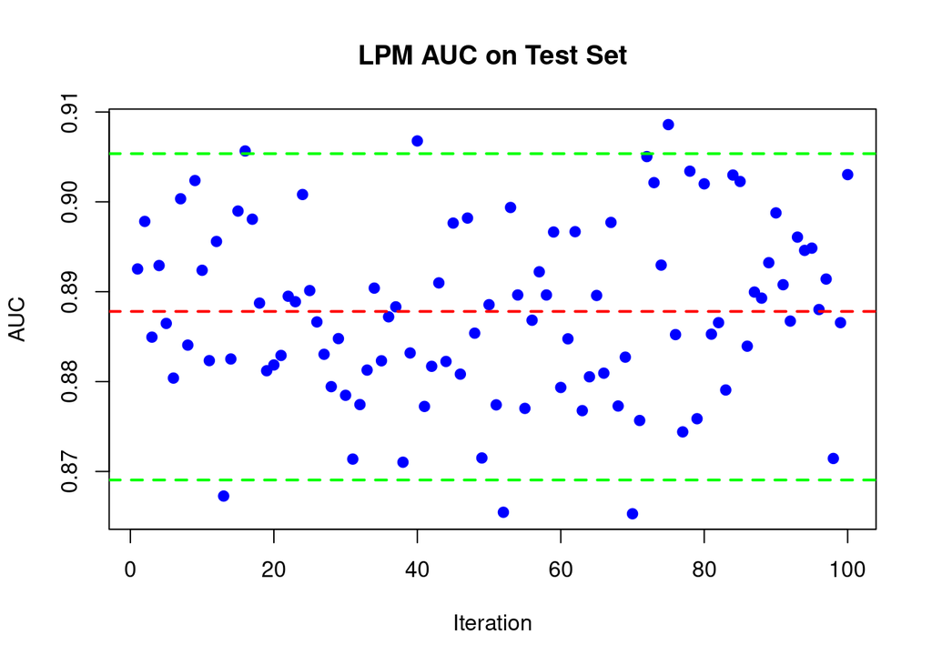

```r
#plot result based 95% CI
plot(auc_lpm, pch = 19, col = "blue", xlab = "Iteration", ylab = "AUC", main = "LPM AUC on Test Set")
abline(h = mean(auc_lpm), lwd = 2, lty = 2, col = "red")
abline(h = quantile(auc_lpm, 0.025), lwd = 2, lty = 2, col = "green")
abline(h = quantile(auc_lpm, 0.975), lwd = 2, lty = 2, col = "green")
```

## 2.3 Report the variable importance by MDI for the top 6 predictors using Random Forest.

### 2.3.1 measuring variable importance for Random forest for both MDI and MDA

```r
# measuring variable importance for Random forest for both MDI and MDA
library(randomForest)

rf_model <- randomForest(y ~ ., data = df1, ntree = 1500,importance = TRUE) #create a random forest model

var_importance <- importance(rf_model)


# Now, try extracting the top 6 predictors by MDI
top_6_predictors <- head(sort(var_importance[, "MeanDecreaseGini"], decreasing = TRUE), 6)

# Print the top 6 predictors
cat("Top 6 predictors by MDI:\n")
```

```
Top 6 predictors by MDI:
```

```r
print(top_6_predictors)
```

```
 duration     month   balance       age       day       job
254.29912 107.83471  83.53760  81.48485  76.30739  71.32107
```

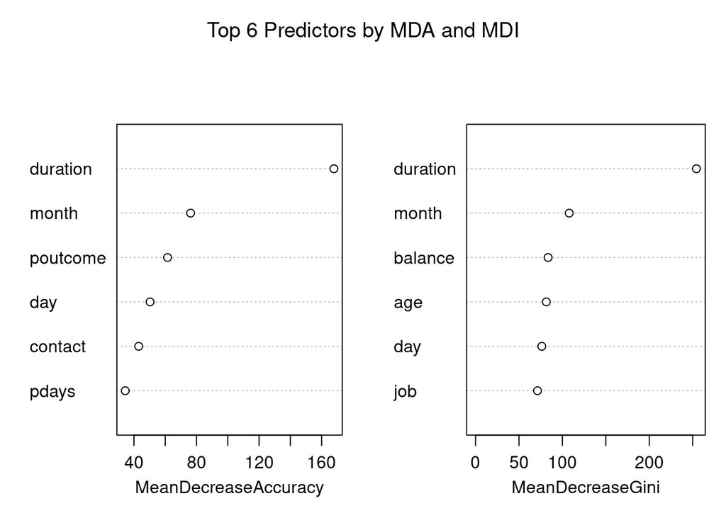

```r
#showing the top 6 predictors
varImpPlot(rf_model, n.var = 6, main = "Top 6 Predictors by MDA and MDI")
```

```r
#plot multi way importance
install.packages("randomForestExplainer", repos = "https://mirror.csclub.uwaterloo.ca/CRAN/")
library(randomForestExplainer)

importance_frame <- measure_importance(rf_model)

# Print column names of the importance_frame
print(colnames(importance_frame))
```

```
[1] "variable"          "mean_min_depth"    "no_of_nodes"
[4] "accuracy_decrease" "gini_decrease"     "no_of_trees"
[7] "times_a_root"      "p_value"
```

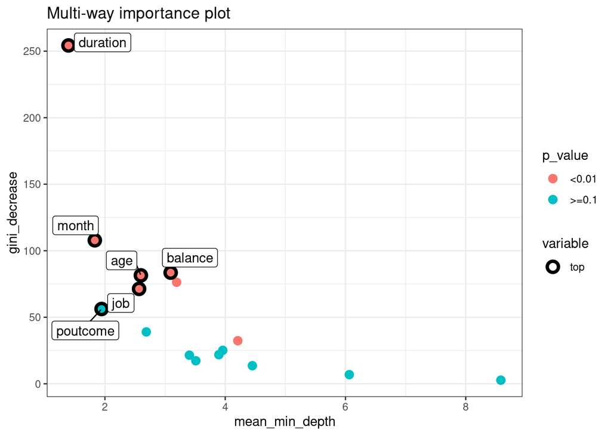

```r
plot_multi_way_importance(importance_frame, x_measure = "mean_min_depth",
                          y_measure = "gini_decrease",
                          size_measure = "p_value", no_of_labels = 6)
```

# 3 Apply GBM with gbm (Bernoulli)

```r
#loading libraries
library(gbm)
library(caret)
library(dplyr)
library(readr)
library(skimr)
library(randomForest)
library(ROCR)
```

## 3.1 Step 1

```r
#gbm
df2 <- df1
df2$y <- ifelse(df2$y == "yes", 1, 0) #numerical outcome 1 and 0, check menu of GBM

grid <- expand.grid(
  shrinkage = seq(0.1, 0.5, by = 0.1),
  interaction.depth = seq(1, 5, by = 1),
  error = NA,
  best.tree = NA
)
#calculate how many rows we have for the grid
nrow(grid)
```

```
[1] 25
```

```r
# run grid search one time to get a sets of best parameters and get corresponding AUC

# test/train split

ind <- sample(nrow(df2), nrow(df2) * 0.8)
dfm <- df2[ind, ]
test <- df2[-ind, ]

for (i in 1:nrow(grid)) {
  model <- gbm(y ~ ., data = dfm,
               distribution = "bernoulli",
               n.trees = 1000,
               interaction.depth = grid$interaction.depth[i],
               shrinkage = grid$shrinkage[i],
               cv.folds = 5,
               n.cores = 8)

  grid$error[i] <- min(model$cv.error)
  grid$best.tree[i] <- which.min(model$cv.error)
}

#getting the best parameters
best_index <- which.min(grid$error)
best_params <- grid[best_index, ]
best_params
```

```
   shrinkage interaction.depth     error best.tree
16       0.1                 4 0.4666126        77
```

```r
finalModel <- gbm(y ~ ., data = dfm, distribution = "bernoulli",
                  n.trees = best_params$best.tree,
                  interaction.depth = best_params$interaction.depth,
                  shrinkage = best_params$shrinkage,
                  n.cores = 8)

phat <- predict(finalModel, test, type = "response")

# Best AUC
# AUC of the best model is
pred <- prediction(phat, test$y)
perf <- performance(pred, "auc")
perf@y.values[[1]]
```

```
[1] 0.8957083
```

## 3.2 Step 2

```r
#using existing best_params$best.tree, best_params$interaction.depth, best_params$shrinkage
#50 loops
library(gbm)

AUC_best <- c()
#create a container for gbm model
model_list <- vector("list", 50)

for (j in 1:50) {

# bootstrapping
ind_gbm <- sample(nrow(df2), nrow(df2), replace = TRUE)
train_gbm <- df2[ind_gbm, ]
test_gbm <- df2[-ind_gbm, ]

finalModel <- gbm(y ~ ., data = train_gbm, distribution = "bernoulli",
                  n.trees = best_params$best.tree,
                  interaction.depth = best_params$interaction.depth,
                  shrinkage = best_params$shrinkage,
                  n.cores = 8) #internal training and split

#save teh model to container
model_list[[j]] <- finalModel

phat_gbm <- predict(finalModel, test_gbm, type = "response")

# AUC
pred_gbm <- prediction(phat_gbm, test_gbm$y)
perf_gbm <- performance(pred_gbm, "auc")
AUC_best[j] <- perf_gbm@y.values[[1]]
}
print(mean(AUC_best))
```

```
[1] 0.9002384
```

```r
#get the index of the best AUC
best_index_gbm <- which.max(AUC_best)
#get the best model
best_model_gbm <- model_list[[best_index_gbm]]
```

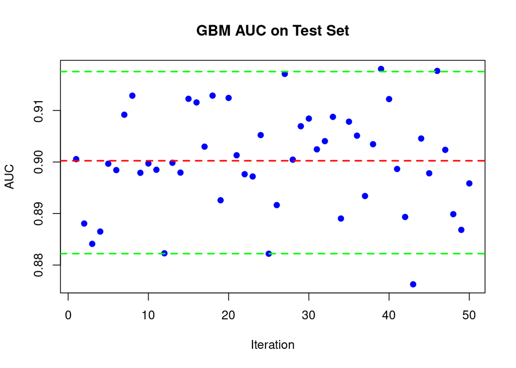

```r
#plot result based 95% CI
plot(AUC_best, pch = 19, col = "blue", xlab = "Iteration", ylab = "AUC", main = "GBM AUC on Test Set")
abline(h = mean(AUC_best), lwd = 2, lty = 2, col = "red")
abline(h = quantile(AUC_best, 0.025), lwd = 2, lty = 2, col = "green")
abline(h = quantile(AUC_best, 0.975), lwd = 2, lty = 2, col = "green")
```

## 3.3 Step 3

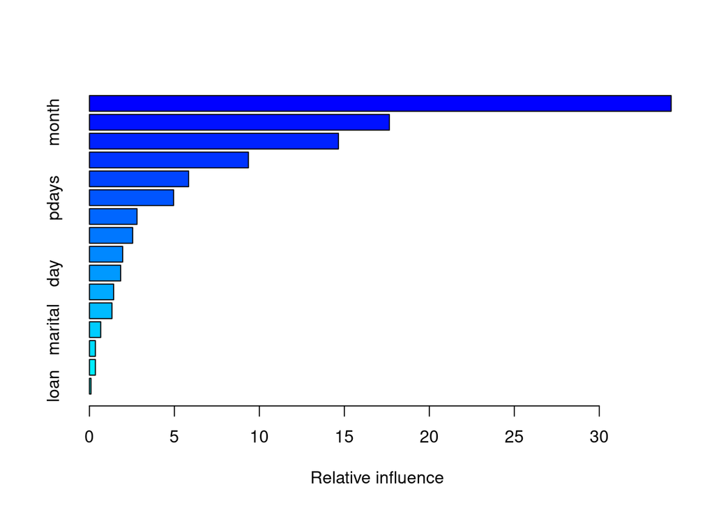

```
                var     rel.inf
duration   duration 34.22926802
month         month 17.64784797
poutcome   poutcome 14.65209658
job             job  9.35352299
age             age  5.83532165
pdays         pdays  4.95095515
balance     balance  2.79859833
previous   previous  2.54279258
contact     contact  1.95351682
day             day  1.83743408
campaign   campaign  1.42192855
education education  1.32410373
marital     marital  0.66227810
housing     housing  0.34944199
default     default  0.34940226
loan           loan  0.09149118
```

```r
#plot the variable importance for the winning model

library(gbm)

summary.gbm(best_model_gbm)
```

# 4 Bonus questions

## 4.1 Try the same steps in (3) with xgboost and compare the results.

### 4.1.1 step 1

```r
library(gbm)
library(caret)
library(dplyr)
library(readr)
library(skimr)
library(xgboost)
library(randomForest)
library(ROCR)
# Prepare the data

df_xgb <- df2

ind <- sample(nrow(df_xgb), nrow(df_xgb)*0.80, replace = FALSE)
train <- df_xgb[ind, ]
test <- df_xgb[-ind, ]

# One-hot coding using R's `model.matrix`
ty <- train$y
tsy <- test$y
hot_tr <- model.matrix(~. -1, data = train[,-which(names(train) == "y")])
hot_ts <- model.matrix(~. -1, data = test[,-which(names(train) == "y")])

# Convert the matrices to DMatrix objects
dtrain <- xgb.DMatrix(data = hot_tr, label = ty)
dtest <- xgb.DMatrix(data = hot_ts, label = tsy)


# Define the parameter grid
param_grid <- expand.grid(
  eta = c(0.01, 0.1, 0.3, 0.4, 0.5),  # Learning rate
  max_depth = c(1, 2, 3, 4, 5),      # Depth of tree
  min_child_weight = c(1, 2)  # Minimum sum of instance weight (hessian) needed in a child
)

best_auc <- 0
best_params <- list()
best_nround <- NULL

for (i in 1:nrow(param_grid)) {
  params <- list(
    booster = "gbtree",
    objective = "binary:logistic",
    eta = param_grid$eta[i],
    max_depth = param_grid$max_depth[i],
    min_child_weight = param_grid$min_child_weight[i],
    eval_metric = "auc"
  )

  # Perform cross-validation
  xgb_cv <- xgb.cv(params = params,
                   data = dtrain,
                   nrounds = 1000,
                   nfold = 5,
                   stratified = TRUE,
                   maximize = FALSE,
                   verbose = 0)  # Suppress verbose output

  max_auc <- max(xgb_cv$evaluation_log$test_auc_mean)
  best_nround <- which.max(xgb_cv$evaluation_log$test_auc_mean)

  if (max_auc > best_auc) {
    best_auc <- max_auc
    best_params <- params
    best_nrounds_for_best_params <- best_nround
  }
}
finalModel_xg <- xgb.train(data = dtrain, params = best_params, nrounds = best_nround,
                        verbose = 0)  # Optionally suppress verbose output during training

# Predictions and AUC calculation
phat_xg <- predict(finalModel_xg, dtest)
pred_xg <- prediction(phat_xg, tsy)
perf_xg <- performance(pred_xg, "auc")
auc_score_xg <- perf_xg@y.values[[1]]

# Print the best AUC score
print(paste("Best xgboost AUC Score:", auc_score_xg))
```

```
[1] "Best xgboost AUC Score: 0.869718906616953"
```

### 4.1.2 step2

```r
# Train the final model with the best parameters
AUC_best_xg <- c()

#create a container for gbm model
model_list_xg <- vector("list", 50)

for (j in 1:50) {

# bootstrapping
ind_xg <- sample(nrow(df_xgb), nrow(df_xgb), replace = TRUE)
train_xg <- df_xgb[ind_xg, ]
test_xg <- df_xgb[-ind_xg, ]

# One-hot coding using R's `model.matrix`
ty2 <- train_xg$y
tsy2 <- test_xg$y
hot_tr2 <- model.matrix(~. -1, data = train_xg[,-which(names(train_xg) == "y")])
hot_ts2 <- model.matrix(~. -1, data = test_xg[,-which(names(train_xg) == "y")])

# Convert the matrices to DMatrix objects
dtrain_xg <- xgb.DMatrix(data = hot_tr2, label = ty2)
dtest_xg <- xgb.DMatrix(data = hot_ts2, label = tsy2)

finalModel_xg2 <- xgb.train(data = dtrain_xg, params = best_params, nrounds = best_nround,
                        verbose = 0)  # Optionally suppress verbose output during training
#save the model to container
model_list_xg[[j]] <- finalModel_xg2

# Predictions and AUC calculation
phat_xg2 <- predict(finalModel_xg2, dtest_xg)
pred_xg2 <- prediction(phat_xg2, tsy2)
perf_xg2 <- performance(pred_xg2, "auc")
AUC_best_xg[j] <- perf_xg2@y.values[[1]]

}
# Print the best AUC score
print(paste("mean trained xgboost AUC Score:", mean(AUC_best_xg)))
```

```
[1] "mean trained xgboost AUC Score: 0.849576327226044"
```

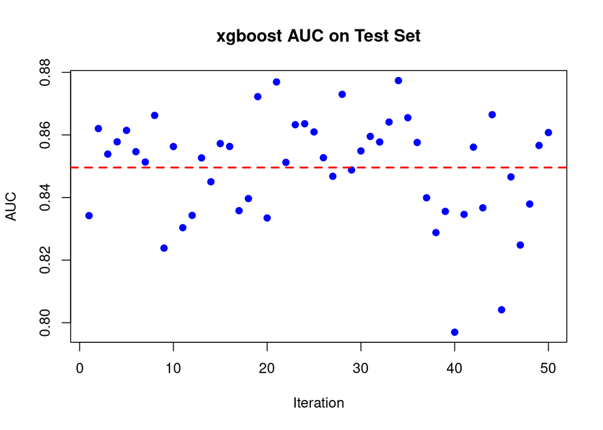

```r
#plot result based 95% CI
plot(AUC_best_xg, pch = 19, col = "blue", xlab = "Iteration", ylab = "AUC", main = "xgboost AUC on Test Set")
abline(h = mean(AUC_best_xg), lwd = 2, lty = 2, col = "red")
abline(h = quantile(AUC_best, 0.025), lwd = 2, lty = 2, col = "green")
abline(h = quantile(AUC_best, 0.975), lwd = 2, lty = 2, col = "green")
```

### 4.1.3 step 3

```r
#plot the variable importance for the winning model
#get the best model
best_model_xg <- model_list_xg[[which.max(AUC_best_xg)]]

# Compute feature importance matrix
importance_matrix = xgb.importance(colnames(dtrain_xg), model = best_model_xg)
importance_matrix
```

```
               Feature         Gain        Cover   Frequency
                <char>        <num>        <num>       <num>
 1:           duration 0.4787322885 0.3768514556 0.214569536
 2:    poutcomesuccess 0.2051593918 0.1859462858 0.049006623
 3:                age 0.0454592050 0.1155295346 0.095364238
 4:              pdays 0.0395065631 0.0465259749 0.086092715
 5:            balance 0.0334947238 0.0100025918 0.132450331
 6:     contactunknown 0.0323226819 0.0404915005 0.023841060
 7:           previous 0.0261670970 0.0157737558 0.049006623
 8:           monthjun 0.0247320051 0.0191255159 0.015894040
 9:                day 0.0228753344 0.0071159968 0.067549669
10:     maritalmarried 0.0227036289 0.0114096480 0.025165563
11:  educationtertiary 0.0095742078 0.0018993687 0.022516556
12:   educationunknown 0.0089205411 0.0044494564 0.029139073
13:           monthoct 0.0080165131 0.1028073372 0.038410596
```

[output cut: 16 more lines]

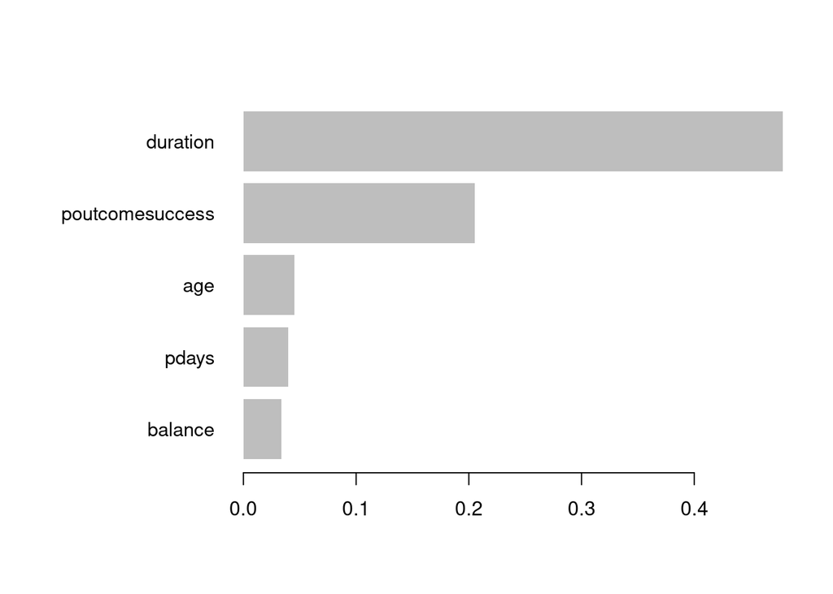

```r
# Nice graph
xgb.plot.importance(importance_matrix[1:5,])
```